# Exploratory Data Analysis of Air quality data in Indian cities

## Group :008

## Section:003

### Dataset Information

- Source : Kaggle https://www.kaggle.com/neomatrix369/air-quality-data-in-india-extended
- Description :This file is available on "Kaggle" and the name of the dataset is "Air Quality Data in India Extended". In a search report on air pollution in India which is published by the Health Effects Institute in 2018,it is concluded that air pollution was associated for 1.1 million deaths in India in 2015. [4]
- Future use : This dataset can be useful to prevent Air Pollution, which helps to higher authories to mitigate this problem.

### Install and Import necessary library

```python
import numpy as np # linear algebra
import pandas as pd # data processing, CSV file I/O (e.g. pd.read_csv)
import matplotlib.pyplot as plt
import seaborn as sns
from matplotlib.gridspec import GridSpec
```

```python
# pd.__version__ shows the version of Pandas without its dependencies
pd.__version__
```

```
'1.2.4'
```

```python
pd.show_versions()
```

[output not shown]

# Load the data

```python
city_day = pd.read_csv("Desktop/city_day.csv")
#city_hour_trans= pd.read_csv("Desktop/city_hour_transformed.csv")
#city_hours = pd.read_csv("Desktop/city_hour.csv")
city_day_trans = pd.read_csv("Desktop/city_day_transformed.csv")
#city_day_transformed_fth = pd.read_csv("Desktop/city_day_transformed.fth.csv")
station_day= pd.read_csv("Desktop/station_day.csv")
station_day_transformed= pd.read_csv("Desktop/Station_day_transformed.csv")
city_day_trans
city_day
#station_day_transformend
station_day
```

|  | StationId | Date | PM2.5 | PM10 | NO | NO2 | NOx | NH3 | CO | SO2 | O3 | Benzene | Toluene | Xylene | AQI | AQI_Bucket |
| --- | --- | --- | --- | --- | --- | --- | --- | --- | --- | --- | --- | --- | --- | --- | --- | --- |
| 0 | AP001 | 2017-11-24 | 71.36 | 115.75 | 1.75 | 20.65 | 12.40 | 12.19 | 0.10 | 10.76 | 109.26 | 0.17 | 5.92 | 0.10 | NaN | NaN |
| 1 | AP001 | 2017-11-25 | 81.40 | 124.50 | 1.44 | 20.50 | 12.08 | 10.72 | 0.12 | 15.24 | 127.09 | 0.20 | 6.50 | 0.06 | 184.0 | Moderate |
| 2 | AP001 | 2017-11-26 | 78.32 | 129.06 | 1.26 | 26.00 | 14.85 | 10.28 | 0.14 | 26.96 | 117.44 | 0.22 | 7.95 | 0.08 | 197.0 | Moderate |
| 3 | AP001 | 2017-11-27 | 88.76 | 135.32 | 6.60 | 30.85 | 21.77 | 12.91 | 0.11 | 33.59 | 111.81 | 0.29 | 7.63 | 0.12 | 198.0 | Moderate |
| 4 | AP001 | 2017-11-28 | 64.18 | 104.09 | 2.56 | 28.07 | 17.01 | 11.42 | 0.09 | 19.00 | 138.18 | 0.17 | 5.02 | 0.07 | 188.0 | Moderate |
| ... | ... | ... | ... | ... | ... | ... | ... | ... | ... | ... | ... | ... | ... | ... | ... | ... |
| 108030 | WB013 | 2020-06-27 | 8.65 | 16.46 | NaN | NaN | NaN | NaN | 0.69 | 4.36 | 30.59 | 1.32 | 7.26 | NaN | 50.0 | Good |
| 108031 | WB013 | 2020-06-28 | 11.80 | 18.47 | NaN | NaN | NaN | NaN | 0.68 | 3.49 | 38.95 | 1.42 | 7.92 | NaN | 65.0 | Satisfactory |
| 108032 | WB013 | 2020-06-29 | 18.60 | 32.26 | 13.65 | 200.87 | 214.20 | 11.40 | 0.78 | 5.12 | 38.17 | 3.52 | 8.64 | NaN | 63.0 | Satisfactory |
| 108033 | WB013 | 2020-06-30 | 16.07 | 39.30 | 7.56 | 29.13 | 36.69 | 29.26 | 0.69 | 5.88 | 29.64 | 1.86 | 8.40 | NaN | 57.0 | Satisfactory |
| 108034 | WB013 | 2020-07-01 | 10.50 | 36.50 | 7.78 | 22.50 | 30.25 | 27.23 | 0.58 | 2.80 | 13.10 | 1.31 | 7.39 | NaN | 59.0 | Satisfactory |

108035 rows × 16 columns

# Simple Data Exploration

```python
#To Check the column names

print(list(city_day.columns))
```

```
['City', 'Date', 'PM2.5', 'PM10', 'NO', 'NO2', 'NOx', 'NH3', 'CO', 'SO2', 'O3', 'Benzene', 'Toluene', 'Xylene', 'AQI', 'AQI_Bucket']
```

```python
print(list(station_day.columns))
```

```
['StationId', 'Date', 'PM2.5', 'PM10', 'NO', 'NO2', 'NOx', 'NH3', 'CO', 'SO2', 'O3', 'Benzene', 'Toluene', 'Xylene', 'AQI', 'AQI_Bucket']
```

```python
# total number of rows and columns of station_day dataframe
station_day.shape
```

```
(108035, 16)
```

# Understand the data by using head() and tail () functions

```python
#Fetch first ten rows from the dataframe
city_day.head(10)
```

|  | City | Date | PM2.5 | PM10 | NO | NO2 | NOx | NH3 | CO | SO2 | O3 | Benzene | Toluene | Xylene | AQI | AQI_Bucket |
| --- | --- | --- | --- | --- | --- | --- | --- | --- | --- | --- | --- | --- | --- | --- | --- | --- |
| 0 | Ahmedabad | 01-01-2015 | NaN | NaN | 0.92 | 18.22 | 17.15 | NaN | 0.92 | 27.64 | 133.36 | 0.00 | 0.02 | 0.00 | NaN | NaN |
| 1 | Ahmedabad | 02-01-2015 | NaN | NaN | 0.97 | 15.69 | 16.46 | NaN | 0.97 | 24.55 | 34.06 | 3.68 | 5.50 | 3.77 | NaN | NaN |
| 2 | Ahmedabad | 03-01-2015 | NaN | NaN | 17.40 | 19.30 | 29.70 | NaN | 17.40 | 29.07 | 30.70 | 6.80 | 16.40 | 2.25 | NaN | NaN |
| 3 | Ahmedabad | 04-01-2015 | NaN | NaN | 1.70 | 18.48 | 17.97 | NaN | 1.70 | 18.59 | 36.08 | 4.43 | 10.14 | 1.00 | NaN | NaN |
| 4 | Ahmedabad | 05-01-2015 | NaN | NaN | 22.10 | 21.42 | 37.76 | NaN | 22.10 | 39.33 | 39.31 | 7.01 | 18.89 | 2.78 | NaN | NaN |
| 5 | Ahmedabad | 06-01-2015 | NaN | NaN | 45.41 | 38.48 | 81.50 | NaN | 45.41 | 45.76 | 46.51 | 5.42 | 10.83 | 1.93 | NaN | NaN |
| 6 | Ahmedabad | 07-01-2015 | NaN | NaN | 112.16 | 40.62 | 130.77 | NaN | 112.16 | 32.28 | 33.47 | 0.00 | 0.00 | 0.00 | NaN | NaN |
| 7 | Ahmedabad | 08-01-2015 | NaN | NaN | 80.87 | 36.74 | 96.75 | NaN | 80.87 | 38.54 | 31.89 | 0.00 | 0.00 | 0.00 | NaN | NaN |
| 8 | Ahmedabad | 09-01-2015 | NaN | NaN | 29.16 | 31.00 | 48.00 | NaN | 29.16 | 58.68 | 25.75 | 0.00 | 0.00 | 0.00 | NaN | NaN |
| 9 | Ahmedabad | 10-01-2015 | NaN | NaN | NaN | 7.04 | 0.00 | NaN | NaN | 8.29 | 4.55 | 0.00 | 0.00 | 0.00 | NaN | NaN |

```python
# fetch last ten rows from the database
city_day.tail(10)
```

|  | City | Date | PM2.5 | PM10 | NO | NO2 | NOx | NH3 | CO | SO2 | O3 | Benzene | Toluene | Xylene | AQI | AQI_Bucket |
| --- | --- | --- | --- | --- | --- | --- | --- | --- | --- | --- | --- | --- | --- | --- | --- | --- |
| 29521 | Visakhapatnam | 22-06-2020 | 33.17 | 108.22 | 5.58 | 42.45 | 27.06 | 13.70 | 0.73 | 13.65 | 34.85 | 3.99 | 10.24 | 2.32 | 95.0 | Satisfactory |
| 29522 | Visakhapatnam | 23-06-2020 | 25.40 | 83.38 | 2.76 | 34.09 | 19.92 | 13.13 | 0.54 | 10.40 | 43.27 | 2.88 | 12.03 | 1.33 | 100.0 | Satisfactory |
| 29523 | Visakhapatnam | 24-06-2020 | 34.36 | 90.90 | 1.22 | 23.38 | 13.12 | 14.45 | 0.56 | 10.92 | 35.12 | 2.99 | 3.15 | 1.60 | 86.0 | Satisfactory |
| 29524 | Visakhapatnam | 25-06-2020 | 13.45 | 58.54 | 2.30 | 21.60 | 13.09 | 12.27 | 0.41 | 8.19 | 29.38 | 1.28 | 5.64 | 0.92 | 77.0 | Satisfactory |
| 29525 | Visakhapatnam | 26-06-2020 | 7.63 | 32.27 | 5.91 | 23.27 | 17.19 | 11.15 | 0.46 | 6.87 | 19.90 | 1.45 | 5.37 | 1.45 | 47.0 | Good |
| 29526 | Visakhapatnam | 27-06-2020 | 15.02 | 50.94 | 7.68 | 25.06 | 19.54 | 12.47 | 0.47 | 8.55 | 23.30 | 2.24 | 12.07 | 0.73 | 41.0 | Good |
| 29527 | Visakhapatnam | 28-06-2020 | 24.38 | 74.09 | 3.42 | 26.06 | 16.53 | 11.99 | 0.52 | 12.72 | 30.14 | 0.74 | 2.21 | 0.38 | 70.0 | Satisfactory |
| 29528 | Visakhapatnam | 29-06-2020 | 22.91 | 65.73 | 3.45 | 29.53 | 18.33 | 10.71 | 0.48 | 8.42 | 30.96 | 0.01 | 0.01 | 0.00 | 68.0 | Satisfactory |
| 29529 | Visakhapatnam | 30-06-2020 | 16.64 | 49.97 | 4.05 | 29.26 | 18.80 | 10.03 | 0.52 | 9.84 | 28.30 | 0.00 | 0.00 | 0.00 | 54.0 | Satisfactory |
| 29530 | Visakhapatnam | 01-07-2020 | 15.00 | 66.00 | 0.40 | 26.85 | 14.05 | 5.20 | 0.59 | 2.10 | 17.05 | NaN | NaN | NaN | 50.0 | Good |

# DataFrames vs. Series

```python
#find the datatype by using type() function.
type(city_day)
```

```
pandas.core.frame.DataFrame
```

```python
#fetch particular row from dataframe
city_day['NO2']
```

```
0        18.22
1        15.69
2        19.30
3        18.48
4        21.42
         ...
29526    25.06
29527    26.06
29528    29.53
29529    29.26
29530    26.85
Name: NO2, Length: 29531, dtype: float64
```

```python
type(city_day['NO2'])
```

```
pandas.core.series.Series
```

```python
#describe()
city_day.describe()
```

|  | PM2.5 | PM10 | NO | NO2 | NOx | NH3 | CO | SO2 | O3 | Benzene | Toluene | Xylene | AQI |
| --- | --- | --- | --- | --- | --- | --- | --- | --- | --- | --- | --- | --- | --- |
| count | 24933.000000 | 18391.000000 | 25949.000000 | 25946.000000 | 25346.000000 | 19203.000000 | 27472.000000 | 25677.000000 | 25509.000000 | 23908.000000 | 21490.000000 | 11422.000000 | 24850.000000 |
| mean | 67.450578 | 118.127103 | 17.574730 | 28.560659 | 32.309123 | 23.483476 | 2.248598 | 14.531977 | 34.491430 | 3.280840 | 8.700972 | 3.070128 | 166.463581 |
| std | 64.661449 | 90.605110 | 22.785846 | 24.474746 | 31.646011 | 25.684275 | 6.962884 | 18.133775 | 21.694928 | 15.811136 | 19.969164 | 6.323247 | 140.696585 |
| min | 0.040000 | 0.010000 | 0.020000 | 0.010000 | 0.000000 | 0.010000 | 0.000000 | 0.010000 | 0.010000 | 0.000000 | 0.000000 | 0.000000 | 13.000000 |
| 25% | 28.820000 | 56.255000 | 5.630000 | 11.750000 | 12.820000 | 8.580000 | 0.510000 | 5.670000 | 18.860000 | 0.120000 | 0.600000 | 0.140000 | 81.000000 |
| 50% | 48.570000 | 95.680000 | 9.890000 | 21.690000 | 23.520000 | 15.850000 | 0.890000 | 9.160000 | 30.840000 | 1.070000 | 2.970000 | 0.980000 | 118.000000 |
| 75% | 80.590000 | 149.745000 | 19.950000 | 37.620000 | 40.127500 | 30.020000 | 1.450000 | 15.220000 | 45.570000 | 3.080000 | 9.150000 | 3.350000 | 208.000000 |
| max | 949.990000 | 1000.000000 | 390.680000 | 362.210000 | 467.630000 | 352.890000 | 175.810000 | 193.860000 | 257.730000 | 455.030000 | 454.850000 | 170.370000 | 2049.000000 |

```python
type(city_day[['Benzene']])
```

```
pandas.core.frame.DataFrame
```

```python
# To check the total number of rows and columns by using .shape
```

```python
city_day.shape
```

```
(29531, 16)
```

```python
# To view columns name
```

```python
city_day.columns
```

```
Index(['City', 'Date', 'PM2.5', 'PM10', 'NO', 'NO2', 'NOx', 'NH3', 'CO', 'SO2',
       'O3', 'Benzene', 'Toluene', 'Xylene', 'AQI', 'AQI_Bucket'],
      dtype='object')
```

```python
# Find unique values
```

```python
city_day.nunique
```

```
<bound method DataFrame.nunique of                 City        Date  PM2.5   PM10     NO    NO2    NOx    NH3  \
0          Ahmedabad  01-01-2015    NaN    NaN   0.92  18.22  17.15    NaN
1          Ahmedabad  02-01-2015    NaN    NaN   0.97  15.69  16.46    NaN
2          Ahmedabad  03-01-2015    NaN    NaN  17.40  19.30  29.70    NaN
3          Ahmedabad  04-01-2015    NaN    NaN   1.70  18.48  17.97    NaN
4          Ahmedabad  05-01-2015    NaN    NaN  22.10  21.42  37.76    NaN
...              ...         ...    ...    ...    ...    ...    ...    ...
29526  Visakhapatnam  27-06-2020  15.02  50.94   7.68  25.06  19.54  12.47
29527  Visakhapatnam  28-06-2020  24.38  74.09   3.42  26.06  16.53  11.99
29528  Visakhapatnam  29-06-2020  22.91  65.73   3.45  29.53  18.33  10.71
29529  Visakhapatnam  30-06-2020  16.64  49.97   4.05  29.26  18.80  10.03
29530  Visakhapatnam  01-07-2020  15.00  66.00   0.40  26.85  14.05   5.20

          CO    SO2      O3  Benzene  Toluene  Xylene   AQI    AQI_Bucket
0       0.92  27.64  133.36     0.00     0.02    0.00   NaN           NaN
1       0.97  24.55   34.06     3.68     5.50    3.77   NaN           NaN
2      17.40  29.07   30.70     6.80    16.40    2.25   NaN           NaN
3       1.70  18.59   36.08     4.43    10.14    1.00   NaN           NaN
4      22.10  39.33   39.31     7.01    18.89    2.78   NaN           NaN
...      ...    ...     ...      ...      ...     ...   ...           ...
29526   0.47   8.55   23.30     2.24    12.07    0.73  41.0          Good
29527   0.52  12.72   30.14     0.74     2.21    0.38  70.0  Satisfactory
29528   0.48   8.42   30.96     0.01     0.01    0.00  68.0  Satisfactory
29529   0.52   9.84   28.30     0.00     0.00    0.00  54.0  Satisfactory
29530   0.59   2.10   17.05      NaN      NaN     NaN  50.0          Good

[29531 rows x 16 columns]>
```

```python
# IDENTIFY THE DATATYPE

city_day.info()
```

```
<class 'pandas.core.frame.DataFrame'>
RangeIndex: 29531 entries, 0 to 29530
Data columns (total 16 columns):
 #   Column      Non-Null Count  Dtype
---  ------      --------------  -----
 0   City        29531 non-null  object
 1   Date        29531 non-null  object
 2   PM2.5       24933 non-null  float64
 3   PM10        18391 non-null  float64
 4   NO          25949 non-null  float64
 5   NO2         25946 non-null  float64
 6   NOx         25346 non-null  float64
 7   NH3         19203 non-null  float64
 8   CO          27472 non-null  float64
 9   SO2         25677 non-null  float64
 10  O3          25509 non-null  float64
 11  Benzene     23908 non-null  float64
 12  Toluene     21490 non-null  float64
 13  Xylene      11422 non-null  float64
 14  AQI         24850 non-null  float64
 15  AQI_Bucket  24850 non-null  object
dtypes: float64(13), object(3)
memory usage: 3.6+ MB
```

```python
city_day_trans.info()
```

```
<class 'pandas.core.frame.DataFrame'>
RangeIndex: 186670 entries, 0 to 186669
Data columns (total 28 columns):
 #   Column                  Non-Null Count   Dtype
---  ------                  --------------   -----
 0   Unnamed: 0              186670 non-null  int64
 1   City                    186670 non-null  object
 2   Date                    186670 non-null  object
 3   PM2.5                   165862 non-null  float64
 4   PM10                    131747 non-null  float64
 5   NO                      169790 non-null  float64
 6   NO2                     169699 non-null  float64
 7   NOx                     173902 non-null  float64
 8   NH3                     139296 non-null  float64
 9   CO                      182963 non-null  float64
```

[output cut: 20 more lines]

```python
station_day.info()
```

```
<class 'pandas.core.frame.DataFrame'>
RangeIndex: 108035 entries, 0 to 108034
Data columns (total 16 columns):
 #   Column      Non-Null Count   Dtype
---  ------      --------------   -----
 0   StationId   108035 non-null  object
 1   Date        108035 non-null  object
 2   PM2.5       86410 non-null   float64
 3   PM10        65329 non-null   float64
 4   NO          90929 non-null   float64
 5   NO2         91488 non-null   float64
 6   NOx         92535 non-null   float64
 7   NH3         59930 non-null   float64
 8   CO          95037 non-null   float64
 9   SO2         82831 non-null   float64
 10  O3          82467 non-null   float64
 11  Benzene     76580 non-null   float64
 12  Toluene     69333 non-null   float64
 13  Xylene      22898 non-null   float64
 14  AQI         87025 non-null   float64
 15  AQI_Bucket  87025 non-null   object
dtypes: float64(13), object(3)
memory usage: 13.2+ MB
```

```python
value_bins = city_day["NO2"].value_counts()
print(value_bins)
```

```
10.58     24
9.42      23
9.14      18
9.24      17
9.47      17
          ..
45.10      1
49.03      1
56.78      1
97.16      1
140.09     1
Name: NO2, Length: 7404, dtype: int64
```

# Answer questions from EDA slides

# Does the data include missing, incomplete or invalid records?

> yes , dataset contains null , incomplete records. Below mentioned are the number of null values for each column and it is clear that dataset has a lot of missing values because a certain number of rows have small records and many missing or Nan values.

```python
station_day.isnull().sum()
```

```
StationId         0
Date              0
PM2.5         21625
PM10          42706
NO            17106
NO2           16547
NOx           15500
NH3           48105
CO            12998
SO2           25204
O3            25568
Benzene       31455
Toluene       38702
Xylene        85137
AQI           21010
AQI_Bucket    21010
dtype: int64
```

```python
city_day.isnull().sum()
```

```
City              0
Date              0
PM2.5          4598
PM10          11140
NO             3582
NO2            3585
NOx            4185
NH3           10328
CO             2059
SO2            3854
O3             4022
Benzene        5623
Toluene        8041
Xylene        18109
AQI            4681
AQI_Bucket     4681
dtype: int64
```

## -What are the inclusion criteria for your data?

The following variables are the inclusion criteria for this dataset: AQI, AQI Bucket and many gases like NO,CO, NO2, NOx, O3,which are harmful for humans and environment as well.

## -Is the data segmented in groups?

yes, the data segmented into the groups for example, Regions are divided into cityand states.

## - Is the data imbalanced (large number of the records represent a majority class and very few records represent the minority class)?

There are few records in the dataset which are imbalanced, as the observations in each entity are either having incomplete or blank values. Furthermore, numerous columns, such as city and state with division in a maximum number of records represent a majority class, while a small number of records represent a minority class.For instance, in the below horizontal bar graph AQI level has different values in the each state of India.

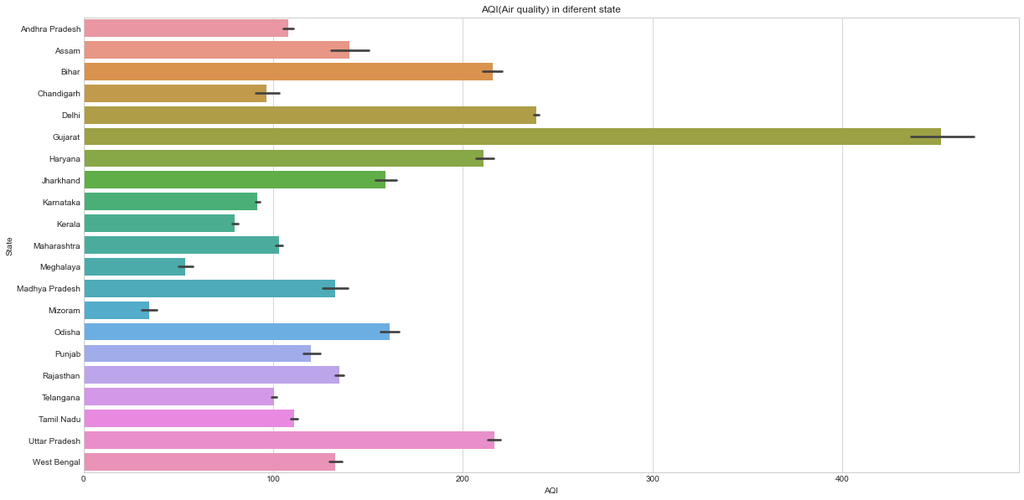

```python
f, ax_ = plt.subplots(1, 1, figsize = (20,10))
sns.barplot(data=station_day_transformed, x='AQI', y='State')
plt.title("AQI(Air quality) in diferent state")
```

## Does the data has any outliers

From the below mentioned horizontal graph,it can be clearly seen that air quality changes due to different season and the points that are far away from the continuous points and lies between 1750 and 2000 AQI are outliers.

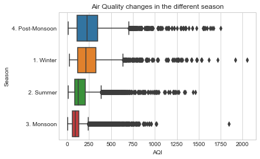

```python
sns.boxplot(data=station_day_transformed, x= 'AQI', y='Season')
plt.title("Air Quality changes in the different season")
```

# Data cleaning and transformation

## 1. Delete Null Rows & Columns:

```python
c_day = city_day.dropna()
```

```python
c_day
```

|  | City | Date | PM2.5 | PM10 | NO | NO2 | NOx | NH3 | CO | SO2 | O3 | Benzene | Toluene | Xylene | AQI | AQI_Bucket |
| --- | --- | --- | --- | --- | --- | --- | --- | --- | --- | --- | --- | --- | --- | --- | --- | --- |
| 2123 | Amaravati | 25-11-2017 | 81.40 | 124.50 | 1.44 | 20.50 | 12.08 | 10.72 | 0.12 | 15.24 | 127.09 | 0.20 | 6.50 | 0.06 | 184.0 | Moderate |
| 2124 | Amaravati | 26-11-2017 | 78.32 | 129.06 | 1.26 | 26.00 | 14.85 | 10.28 | 0.14 | 26.96 | 117.44 | 0.22 | 7.95 | 0.08 | 197.0 | Moderate |
| 2125 | Amaravati | 27-11-2017 | 88.76 | 135.32 | 6.60 | 30.85 | 21.77 | 12.91 | 0.11 | 33.59 | 111.81 | 0.29 | 7.63 | 0.12 | 198.0 | Moderate |
| 2126 | Amaravati | 28-11-2017 | 64.18 | 104.09 | 2.56 | 28.07 | 17.01 | 11.42 | 0.09 | 19.00 | 138.18 | 0.17 | 5.02 | 0.07 | 188.0 | Moderate |
| 2127 | Amaravati | 29-11-2017 | 72.47 | 114.84 | 5.23 | 23.20 | 16.59 | 12.25 | 0.16 | 10.55 | 109.74 | 0.21 | 4.71 | 0.08 | 173.0 | Moderate |
| ... | ... | ... | ... | ... | ... | ... | ... | ... | ... | ... | ... | ... | ... | ... | ... | ... |
| 29525 | Visakhapatnam | 26-06-2020 | 7.63 | 32.27 | 5.91 | 23.27 | 17.19 | 11.15 | 0.46 | 6.87 | 19.90 | 1.45 | 5.37 | 1.45 | 47.0 | Good |
| 29526 | Visakhapatnam | 27-06-2020 | 15.02 | 50.94 | 7.68 | 25.06 | 19.54 | 12.47 | 0.47 | 8.55 | 23.30 | 2.24 | 12.07 | 0.73 | 41.0 | Good |
| 29527 | Visakhapatnam | 28-06-2020 | 24.38 | 74.09 | 3.42 | 26.06 | 16.53 | 11.99 | 0.52 | 12.72 | 30.14 | 0.74 | 2.21 | 0.38 | 70.0 | Satisfactory |
| 29528 | Visakhapatnam | 29-06-2020 | 22.91 | 65.73 | 3.45 | 29.53 | 18.33 | 10.71 | 0.48 | 8.42 | 30.96 | 0.01 | 0.01 | 0.00 | 68.0 | Satisfactory |
| 29529 | Visakhapatnam | 30-06-2020 | 16.64 | 49.97 | 4.05 | 29.26 | 18.80 | 10.03 | 0.52 | 9.84 | 28.30 | 0.00 | 0.00 | 0.00 | 54.0 | Satisfactory |

6236 rows × 16 columns

```python
s_day=station_day.dropna()
```

```python
s_day
```

|  | StationId | Date | PM2.5 | PM10 | NO | NO2 | NOx | NH3 | CO | SO2 | O3 | Benzene | Toluene | Xylene | AQI | AQI_Bucket |
| --- | --- | --- | --- | --- | --- | --- | --- | --- | --- | --- | --- | --- | --- | --- | --- | --- |
| 1 | AP001 | 2017-11-25 | 81.40 | 124.50 | 1.44 | 20.50 | 12.08 | 10.72 | 0.12 | 15.24 | 127.09 | 0.20 | 6.50 | 0.06 | 184.0 | Moderate |
| 2 | AP001 | 2017-11-26 | 78.32 | 129.06 | 1.26 | 26.00 | 14.85 | 10.28 | 0.14 | 26.96 | 117.44 | 0.22 | 7.95 | 0.08 | 197.0 | Moderate |
| 3 | AP001 | 2017-11-27 | 88.76 | 135.32 | 6.60 | 30.85 | 21.77 | 12.91 | 0.11 | 33.59 | 111.81 | 0.29 | 7.63 | 0.12 | 198.0 | Moderate |
| 4 | AP001 | 2017-11-28 | 64.18 | 104.09 | 2.56 | 28.07 | 17.01 | 11.42 | 0.09 | 19.00 | 138.18 | 0.17 | 5.02 | 0.07 | 188.0 | Moderate |
| 5 | AP001 | 2017-11-29 | 72.47 | 114.84 | 5.23 | 23.20 | 16.59 | 12.25 | 0.16 | 10.55 | 109.74 | 0.21 | 4.71 | 0.08 | 173.0 | Moderate |
| ... | ... | ... | ... | ... | ... | ... | ... | ... | ... | ... | ... | ... | ... | ... | ... | ... |
| 106143 | WB010 | 2020-02-10 | 80.93 | 174.84 | 82.96 | 56.74 | 139.70 | 29.32 | 1.18 | 9.36 | 15.96 | 53.71 | 51.38 | 1.30 | 179.0 | Moderate |
| 106144 | WB010 | 2020-02-11 | 103.75 | 217.89 | 139.58 | 63.28 | 181.55 | 27.56 | 1.71 | 11.43 | 24.75 | 53.58 | 55.10 | 2.29 | 226.0 | Poor |
| 106145 | WB010 | 2020-02-12 | 115.40 | 225.76 | 193.19 | 70.41 | 213.77 | 35.25 | 2.11 | 10.49 | 22.11 | 58.61 | 61.42 | 3.20 | 259.0 | Poor |
| 106146 | WB010 | 2020-02-13 | 97.37 | 179.87 | 105.12 | 64.34 | 169.46 | 36.24 | 1.51 | 6.90 | 12.55 | 64.90 | 62.12 | 2.16 | 250.0 | Poor |
| 106147 | WB010 | 2020-02-14 | 89.13 | 179.89 | 78.47 | 56.37 | 134.84 | 37.98 | 1.30 | 8.13 | 23.21 | 69.67 | 66.15 | 2.42 | 223.0 | Poor |

10314 rows × 16 columns

```python
station_day_trans=station_day_transformed.dropna()
```

```python
station_day_trans.fillna("Unknown")
```

|  | unnamed | StationId | Date | PM2.5 | PM10 | NO | NO2 | NOx | NH3 | CO | ... | City | State | Status | Region | Month | Year | Season | Weekday_or_weekend | Regular_day_or_holiday | AQ_Acceptability |
| --- | --- | --- | --- | --- | --- | --- | --- | --- | --- | --- | --- | --- | --- | --- | --- | --- | --- | --- | --- | --- | --- |
| 1 | 1 | AP001 | 25-11-2017 | 81.40 | 124.50 | 1.44 | 20.50 | 12.08 | 10.72 | 0.12 | ... | Amaravati | Andhra Pradesh | Active | 5. Western | 11. Nov | 2017 | 4. Post-Monsoon | Weekend | Regular day | Unacceptable |
| 2 | 2 | AP001 | 26-11-2017 | 78.32 | 129.06 | 1.26 | 26.00 | 14.85 | 10.28 | 0.14 | ... | Amaravati | Andhra Pradesh | Active | 5. Western | 11. Nov | 2017 | 4. Post-Monsoon | Weekend | Regular day | Unacceptable |
| 3 | 3 | AP001 | 27-11-2017 | 88.76 | 135.32 | 6.60 | 30.85 | 21.77 | 12.91 | 0.11 | ... | Amaravati | Andhra Pradesh | Active | 5. Western | 11. Nov | 2017 | 4. Post-Monsoon | Weekday | Regular day | Unacceptable |
| 4 | 4 | AP001 | 28-11-2017 | 64.18 | 104.09 | 2.56 | 28.07 | 17.01 | 11.42 | 0.09 | ... | Amaravati | Andhra Pradesh | Active | 5. Western | 11. Nov | 2017 | 4. Post-Monsoon | Weekday | Regular day | Unacceptable |
| 5 | 5 | AP001 | 29-11-2017 | 72.47 | 114.84 | 5.23 | 23.20 | 16.59 | 12.25 | 0.16 | ... | Amaravati | Andhra Pradesh | Active | 5. Western | 11. Nov | 2017 | 4. Post-Monsoon | Weekday | Regular day | Unacceptable |
| ... | ... | ... | ... | ... | ... | ... | ... | ... | ... | ... | ... | ... | ... | ... | ... | ... | ... | ... | ... | ... | ... |
| 106143 | 106143 | WB010 | 10-02-2020 | 80.93 | 174.84 | 82.96 | 56.74 | 139.70 | 29.32 | 1.18 | ... | Kolkata | West Bengal | Active | 4. Eastern | 02. Feb | 2020 | 1. Winter | Weekday | Regular day | Unacceptable |
| 106144 | 106144 | WB010 | 11-02-2020 | 103.75 | 217.89 | 139.58 | 63.28 | 181.55 | 27.56 | 1.71 | ... | Kolkata | West Bengal | Active | 4. Eastern | 02. Feb | 2020 | 1. Winter | Weekday | Regular day | Unacceptable |
| 106145 | 106145 | WB010 | 12-02-2020 | 115.40 | 225.76 | 193.19 | 70.41 | 213.77 | 35.25 | 2.11 | ... | Kolkata | West Bengal | Active | 4. Eastern | 02. Feb | 2020 | 1. Winter | Weekday | Regular day | Unacceptable |
| 106146 | 106146 | WB010 | 13-02-2020 | 97.37 | 179.87 | 105.12 | 64.34 | 169.46 | 36.24 | 1.51 | ... | Kolkata | West Bengal | Active | 4. Eastern | 02. Feb | 2020 | 1. Winter | Weekday | Regular day | Unacceptable |
| 106147 | 106147 | WB010 | 14-02-2020 | 89.13 | 179.89 | 78.47 | 56.37 | 134.84 | 37.98 | 1.30 | ... | Kolkata | West Bengal | Active | 4. Eastern | 02. Feb | 2020 | 1. Winter | Weekday | Regular day | Unacceptable |

10314 rows × 28 columns

## 2. Sort values by date

```python
c_day.sort_values(by = ["Date"])
```

|  | City | Date | PM2.5 | PM10 | NO | NO2 | NOx | NH3 | CO | SO2 | O3 | Benzene | Toluene | Xylene | AQI | AQI_Bucket |
| --- | --- | --- | --- | --- | --- | --- | --- | --- | --- | --- | --- | --- | --- | --- | --- | --- |
| 10229 | Delhi | 01-01-2015 | 313.22 | 607.98 | 69.16 | 36.39 | 110.59 | 33.85 | 15.20 | 9.25 | 41.68 | 14.36 | 24.86 | 9.84 | 472.0 | Severe |
| 10594 | Delhi | 01-01-2016 | 295.71 | 476.09 | 86.62 | 94.04 | 131.36 | 79.87 | 2.42 | 23.57 | 108.14 | 5.81 | 16.30 | 0.00 | 463.0 | Severe |
| 14943 | Hyderabad | 01-01-2016 | 232.83 | 108.20 | 11.17 | 17.35 | 26.85 | 10.58 | 1.45 | 8.56 | 27.64 | 1.79 | 9.91 | 2.41 | 387.0 | Very Poor |
| 28253 | Visakhapatnam | 01-01-2017 | 63.51 | 97.56 | 9.20 | 38.43 | 25.57 | 11.49 | 1.38 | 1.44 | 55.05 | 6.13 | 8.99 | 6.60 | 147.0 | Moderate |
| 15309 | Hyderabad | 01-01-2017 | 61.25 | 100.46 | 7.54 | 39.37 | 8.27 | 15.38 | 0.25 | 6.08 | 69.11 | 0.02 | 0.20 | 0.03 | 110.0 | Moderate |
| ... | ... | ... | ... | ... | ... | ... | ... | ... | ... | ... | ... | ... | ... | ... | ... | ... |
| 16403 | Hyderabad | 31-12-2019 | 47.37 | 82.17 | 8.73 | 30.94 | 22.41 | 14.24 | 0.68 | 5.25 | 30.96 | 0.68 | 1.91 | 0.04 | 107.0 | Moderate |
| 12054 | Delhi | 31-12-2019 | 245.53 | 338.18 | 44.49 | 47.50 | 64.57 | 48.22 | 1.80 | 11.03 | 28.07 | 4.81 | 38.40 | 0.22 | 417.0 | Severe |
| 4110 | Amritsar | 31-12-2019 | 71.00 | 98.30 | 9.93 | 10.00 | 19.75 | 5.04 | 0.59 | 8.42 | 24.90 | 1.75 | 1.47 | 2.00 | 111.0 | Moderate |
| 19662 | Kolkata | 31-12-2019 | 128.67 | 235.51 | 88.57 | 64.68 | 143.92 | 34.42 | 2.04 | 18.82 | 26.28 | 36.66 | 48.76 | 5.43 | 289.0 | Poor |
| 7650 | Chandigarh | 31-12-2019 | 77.06 | 145.42 | 49.23 | 14.74 | 48.79 | 24.95 | 1.24 | 7.27 | 6.62 | 10.96 | 0.42 | 0.72 | 206.0 | Poor |

6236 rows × 16 columns

```python
## split date column into three different columns as 'day','month' and 'year'
```

```python
city_day_date= city_day_date[["day", "month", "year"]] = c_day["Date"].str.split("-", expand = True)
print("\nNew DataFrame:")
print(city_day_date)
#reference[6]
```

```
New DataFrame:
        0   1     2 day month  year
2123   25  11  2017  25    11  2017
2124   26  11  2017  26    11  2017
2125   27  11  2017  27    11  2017
2126   28  11  2017  28    11  2017
2127   29  11  2017  29    11  2017
...    ..  ..   ...  ..   ...   ...
29525  26  06  2020  26    06  2020
29526  27  06  2020  27    06  2020
29527  28  06  2020  28    06  2020
29528  29  06  2020  29    06  2020
29529  30  06  2020  30    06  2020

[6236 rows x 6 columns]
```

```python
city_day_date.year
```

```
2123     2017
2124     2017
2125     2017
2126     2017
2127     2017
         ...
29525    2020
29526    2020
29527    2020
29528    2020
29529    2020
Name: year, Length: 6236, dtype: object
```

```python
city_day_date=city_day_date.dropna()
```

## 3. Delete unwanted coumn from dataframe

```python
c_day
```

|  | City | Date | PM2.5 | PM10 | NO | NO2 | NOx | NH3 | CO | SO2 | O3 | Benzene | Toluene | Xylene | AQI | AQI_Bucket |
| --- | --- | --- | --- | --- | --- | --- | --- | --- | --- | --- | --- | --- | --- | --- | --- | --- |
| 2123 | Amaravati | 25-11-2017 | 81.40 | 124.50 | 1.44 | 20.50 | 12.08 | 10.72 | 0.12 | 15.24 | 127.09 | 0.20 | 6.50 | 0.06 | 184.0 | Moderate |
| 2124 | Amaravati | 26-11-2017 | 78.32 | 129.06 | 1.26 | 26.00 | 14.85 | 10.28 | 0.14 | 26.96 | 117.44 | 0.22 | 7.95 | 0.08 | 197.0 | Moderate |
| 2125 | Amaravati | 27-11-2017 | 88.76 | 135.32 | 6.60 | 30.85 | 21.77 | 12.91 | 0.11 | 33.59 | 111.81 | 0.29 | 7.63 | 0.12 | 198.0 | Moderate |
| 2126 | Amaravati | 28-11-2017 | 64.18 | 104.09 | 2.56 | 28.07 | 17.01 | 11.42 | 0.09 | 19.00 | 138.18 | 0.17 | 5.02 | 0.07 | 188.0 | Moderate |
| 2127 | Amaravati | 29-11-2017 | 72.47 | 114.84 | 5.23 | 23.20 | 16.59 | 12.25 | 0.16 | 10.55 | 109.74 | 0.21 | 4.71 | 0.08 | 173.0 | Moderate |
| ... | ... | ... | ... | ... | ... | ... | ... | ... | ... | ... | ... | ... | ... | ... | ... | ... |
| 29525 | Visakhapatnam | 26-06-2020 | 7.63 | 32.27 | 5.91 | 23.27 | 17.19 | 11.15 | 0.46 | 6.87 | 19.90 | 1.45 | 5.37 | 1.45 | 47.0 | Good |
| 29526 | Visakhapatnam | 27-06-2020 | 15.02 | 50.94 | 7.68 | 25.06 | 19.54 | 12.47 | 0.47 | 8.55 | 23.30 | 2.24 | 12.07 | 0.73 | 41.0 | Good |
| 29527 | Visakhapatnam | 28-06-2020 | 24.38 | 74.09 | 3.42 | 26.06 | 16.53 | 11.99 | 0.52 | 12.72 | 30.14 | 0.74 | 2.21 | 0.38 | 70.0 | Satisfactory |
| 29528 | Visakhapatnam | 29-06-2020 | 22.91 | 65.73 | 3.45 | 29.53 | 18.33 | 10.71 | 0.48 | 8.42 | 30.96 | 0.01 | 0.01 | 0.00 | 68.0 | Satisfactory |
| 29529 | Visakhapatnam | 30-06-2020 | 16.64 | 49.97 | 4.05 | 29.26 | 18.80 | 10.03 | 0.52 | 9.84 | 28.30 | 0.00 | 0.00 | 0.00 | 54.0 | Satisfactory |

6236 rows × 16 columns

```python
c_day= c_day.drop(['Date'], axis=1)
```

```python
c_day
```

|  | City | PM2.5 | PM10 | NO | NO2 | NOx | NH3 | CO | SO2 | O3 | Benzene | Toluene | Xylene | AQI | AQI_Bucket |
| --- | --- | --- | --- | --- | --- | --- | --- | --- | --- | --- | --- | --- | --- | --- | --- |
| 2123 | Amaravati | 81.40 | 124.50 | 1.44 | 20.50 | 12.08 | 10.72 | 0.12 | 15.24 | 127.09 | 0.20 | 6.50 | 0.06 | 184.0 | Moderate |
| 2124 | Amaravati | 78.32 | 129.06 | 1.26 | 26.00 | 14.85 | 10.28 | 0.14 | 26.96 | 117.44 | 0.22 | 7.95 | 0.08 | 197.0 | Moderate |
| 2125 | Amaravati | 88.76 | 135.32 | 6.60 | 30.85 | 21.77 | 12.91 | 0.11 | 33.59 | 111.81 | 0.29 | 7.63 | 0.12 | 198.0 | Moderate |
| 2126 | Amaravati | 64.18 | 104.09 | 2.56 | 28.07 | 17.01 | 11.42 | 0.09 | 19.00 | 138.18 | 0.17 | 5.02 | 0.07 | 188.0 | Moderate |
| 2127 | Amaravati | 72.47 | 114.84 | 5.23 | 23.20 | 16.59 | 12.25 | 0.16 | 10.55 | 109.74 | 0.21 | 4.71 | 0.08 | 173.0 | Moderate |
| ... | ... | ... | ... | ... | ... | ... | ... | ... | ... | ... | ... | ... | ... | ... | ... |
| 29525 | Visakhapatnam | 7.63 | 32.27 | 5.91 | 23.27 | 17.19 | 11.15 | 0.46 | 6.87 | 19.90 | 1.45 | 5.37 | 1.45 | 47.0 | Good |
| 29526 | Visakhapatnam | 15.02 | 50.94 | 7.68 | 25.06 | 19.54 | 12.47 | 0.47 | 8.55 | 23.30 | 2.24 | 12.07 | 0.73 | 41.0 | Good |
| 29527 | Visakhapatnam | 24.38 | 74.09 | 3.42 | 26.06 | 16.53 | 11.99 | 0.52 | 12.72 | 30.14 | 0.74 | 2.21 | 0.38 | 70.0 | Satisfactory |
| 29528 | Visakhapatnam | 22.91 | 65.73 | 3.45 | 29.53 | 18.33 | 10.71 | 0.48 | 8.42 | 30.96 | 0.01 | 0.01 | 0.00 | 68.0 | Satisfactory |
| 29529 | Visakhapatnam | 16.64 | 49.97 | 4.05 | 29.26 | 18.80 | 10.03 | 0.52 | 9.84 | 28.30 | 0.00 | 0.00 | 0.00 | 54.0 | Satisfactory |

6236 rows × 15 columns

```python
station_day=station_day.drop(['Date'],axis=1)
```

```python
station_day
```

|  | StationId | PM2.5 | PM10 | NO | NO2 | NOx | NH3 | CO | SO2 | O3 | Benzene | Toluene | Xylene | AQI | AQI_Bucket |
| --- | --- | --- | --- | --- | --- | --- | --- | --- | --- | --- | --- | --- | --- | --- | --- |
| 0 | AP001 | 71.36 | 115.75 | 1.75 | 20.65 | 12.40 | 12.19 | 0.10 | 10.76 | 109.26 | 0.17 | 5.92 | 0.10 | NaN | NaN |
| 1 | AP001 | 81.40 | 124.50 | 1.44 | 20.50 | 12.08 | 10.72 | 0.12 | 15.24 | 127.09 | 0.20 | 6.50 | 0.06 | 184.0 | Moderate |
| 2 | AP001 | 78.32 | 129.06 | 1.26 | 26.00 | 14.85 | 10.28 | 0.14 | 26.96 | 117.44 | 0.22 | 7.95 | 0.08 | 197.0 | Moderate |
| 3 | AP001 | 88.76 | 135.32 | 6.60 | 30.85 | 21.77 | 12.91 | 0.11 | 33.59 | 111.81 | 0.29 | 7.63 | 0.12 | 198.0 | Moderate |
| 4 | AP001 | 64.18 | 104.09 | 2.56 | 28.07 | 17.01 | 11.42 | 0.09 | 19.00 | 138.18 | 0.17 | 5.02 | 0.07 | 188.0 | Moderate |
| ... | ... | ... | ... | ... | ... | ... | ... | ... | ... | ... | ... | ... | ... | ... | ... |
| 108030 | WB013 | 8.65 | 16.46 | NaN | NaN | NaN | NaN | 0.69 | 4.36 | 30.59 | 1.32 | 7.26 | NaN | 50.0 | Good |
| 108031 | WB013 | 11.80 | 18.47 | NaN | NaN | NaN | NaN | 0.68 | 3.49 | 38.95 | 1.42 | 7.92 | NaN | 65.0 | Satisfactory |
| 108032 | WB013 | 18.60 | 32.26 | 13.65 | 200.87 | 214.20 | 11.40 | 0.78 | 5.12 | 38.17 | 3.52 | 8.64 | NaN | 63.0 | Satisfactory |
| 108033 | WB013 | 16.07 | 39.30 | 7.56 | 29.13 | 36.69 | 29.26 | 0.69 | 5.88 | 29.64 | 1.86 | 8.40 | NaN | 57.0 | Satisfactory |
| 108034 | WB013 | 10.50 | 36.50 | 7.78 | 22.50 | 30.25 | 27.23 | 0.58 | 2.80 | 13.10 | 1.31 | 7.39 | NaN | 59.0 | Satisfactory |

108035 rows × 15 columns

```python
station_day_trans
```

|  | unnamed | StationId | Date | PM2.5 | PM10 | NO | NO2 | NOx | NH3 | CO | ... | City | State | Status | Region | Month | Year | Season | Weekday_or_weekend | Regular_day_or_holiday | AQ_Acceptability |
| --- | --- | --- | --- | --- | --- | --- | --- | --- | --- | --- | --- | --- | --- | --- | --- | --- | --- | --- | --- | --- | --- |
| 1 | 1 | AP001 | 25-11-2017 | 81.40 | 124.50 | 1.44 | 20.50 | 12.08 | 10.72 | 0.12 | ... | Amaravati | Andhra Pradesh | Active | 5. Western | 11. Nov | 2017 | 4. Post-Monsoon | Weekend | Regular day | Unacceptable |
| 2 | 2 | AP001 | 26-11-2017 | 78.32 | 129.06 | 1.26 | 26.00 | 14.85 | 10.28 | 0.14 | ... | Amaravati | Andhra Pradesh | Active | 5. Western | 11. Nov | 2017 | 4. Post-Monsoon | Weekend | Regular day | Unacceptable |
| 3 | 3 | AP001 | 27-11-2017 | 88.76 | 135.32 | 6.60 | 30.85 | 21.77 | 12.91 | 0.11 | ... | Amaravati | Andhra Pradesh | Active | 5. Western | 11. Nov | 2017 | 4. Post-Monsoon | Weekday | Regular day | Unacceptable |
| 4 | 4 | AP001 | 28-11-2017 | 64.18 | 104.09 | 2.56 | 28.07 | 17.01 | 11.42 | 0.09 | ... | Amaravati | Andhra Pradesh | Active | 5. Western | 11. Nov | 2017 | 4. Post-Monsoon | Weekday | Regular day | Unacceptable |
| 5 | 5 | AP001 | 29-11-2017 | 72.47 | 114.84 | 5.23 | 23.20 | 16.59 | 12.25 | 0.16 | ... | Amaravati | Andhra Pradesh | Active | 5. Western | 11. Nov | 2017 | 4. Post-Monsoon | Weekday | Regular day | Unacceptable |
| ... | ... | ... | ... | ... | ... | ... | ... | ... | ... | ... | ... | ... | ... | ... | ... | ... | ... | ... | ... | ... | ... |
| 106143 | 106143 | WB010 | 10-02-2020 | 80.93 | 174.84 | 82.96 | 56.74 | 139.70 | 29.32 | 1.18 | ... | Kolkata | West Bengal | Active | 4. Eastern | 02. Feb | 2020 | 1. Winter | Weekday | Regular day | Unacceptable |
| 106144 | 106144 | WB010 | 11-02-2020 | 103.75 | 217.89 | 139.58 | 63.28 | 181.55 | 27.56 | 1.71 | ... | Kolkata | West Bengal | Active | 4. Eastern | 02. Feb | 2020 | 1. Winter | Weekday | Regular day | Unacceptable |
| 106145 | 106145 | WB010 | 12-02-2020 | 115.40 | 225.76 | 193.19 | 70.41 | 213.77 | 35.25 | 2.11 | ... | Kolkata | West Bengal | Active | 4. Eastern | 02. Feb | 2020 | 1. Winter | Weekday | Regular day | Unacceptable |
| 106146 | 106146 | WB010 | 13-02-2020 | 97.37 | 179.87 | 105.12 | 64.34 | 169.46 | 36.24 | 1.51 | ... | Kolkata | West Bengal | Active | 4. Eastern | 02. Feb | 2020 | 1. Winter | Weekday | Regular day | Unacceptable |
| 106147 | 106147 | WB010 | 14-02-2020 | 89.13 | 179.89 | 78.47 | 56.37 | 134.84 | 37.98 | 1.30 | ... | Kolkata | West Bengal | Active | 4. Eastern | 02. Feb | 2020 | 1. Winter | Weekday | Regular day | Unacceptable |

10314 rows × 28 columns

```python
station_day_trans = station_day_trans.drop(['unnamed'],axis=1)
```

```python
station_day_trans
```

|  | StationId | Date | PM2.5 | PM10 | NO | NO2 | NOx | NH3 | CO | SO2 | ... | City | State | Status | Region | Month | Year | Season | Weekday_or_weekend | Regular_day_or_holiday | AQ_Acceptability |
| --- | --- | --- | --- | --- | --- | --- | --- | --- | --- | --- | --- | --- | --- | --- | --- | --- | --- | --- | --- | --- | --- |
| 1 | AP001 | 25-11-2017 | 81.40 | 124.50 | 1.44 | 20.50 | 12.08 | 10.72 | 0.12 | 15.24 | ... | Amaravati | Andhra Pradesh | Active | 5. Western | 11. Nov | 2017 | 4. Post-Monsoon | Weekend | Regular day | Unacceptable |
| 2 | AP001 | 26-11-2017 | 78.32 | 129.06 | 1.26 | 26.00 | 14.85 | 10.28 | 0.14 | 26.96 | ... | Amaravati | Andhra Pradesh | Active | 5. Western | 11. Nov | 2017 | 4. Post-Monsoon | Weekend | Regular day | Unacceptable |
| 3 | AP001 | 27-11-2017 | 88.76 | 135.32 | 6.60 | 30.85 | 21.77 | 12.91 | 0.11 | 33.59 | ... | Amaravati | Andhra Pradesh | Active | 5. Western | 11. Nov | 2017 | 4. Post-Monsoon | Weekday | Regular day | Unacceptable |
| 4 | AP001 | 28-11-2017 | 64.18 | 104.09 | 2.56 | 28.07 | 17.01 | 11.42 | 0.09 | 19.00 | ... | Amaravati | Andhra Pradesh | Active | 5. Western | 11. Nov | 2017 | 4. Post-Monsoon | Weekday | Regular day | Unacceptable |
| 5 | AP001 | 29-11-2017 | 72.47 | 114.84 | 5.23 | 23.20 | 16.59 | 12.25 | 0.16 | 10.55 | ... | Amaravati | Andhra Pradesh | Active | 5. Western | 11. Nov | 2017 | 4. Post-Monsoon | Weekday | Regular day | Unacceptable |
| ... | ... | ... | ... | ... | ... | ... | ... | ... | ... | ... | ... | ... | ... | ... | ... | ... | ... | ... | ... | ... | ... |
| 106143 | WB010 | 10-02-2020 | 80.93 | 174.84 | 82.96 | 56.74 | 139.70 | 29.32 | 1.18 | 9.36 | ... | Kolkata | West Bengal | Active | 4. Eastern | 02. Feb | 2020 | 1. Winter | Weekday | Regular day | Unacceptable |
| 106144 | WB010 | 11-02-2020 | 103.75 | 217.89 | 139.58 | 63.28 | 181.55 | 27.56 | 1.71 | 11.43 | ... | Kolkata | West Bengal | Active | 4. Eastern | 02. Feb | 2020 | 1. Winter | Weekday | Regular day | Unacceptable |
| 106145 | WB010 | 12-02-2020 | 115.40 | 225.76 | 193.19 | 70.41 | 213.77 | 35.25 | 2.11 | 10.49 | ... | Kolkata | West Bengal | Active | 4. Eastern | 02. Feb | 2020 | 1. Winter | Weekday | Regular day | Unacceptable |
| 106146 | WB010 | 13-02-2020 | 97.37 | 179.87 | 105.12 | 64.34 | 169.46 | 36.24 | 1.51 | 6.90 | ... | Kolkata | West Bengal | Active | 4. Eastern | 02. Feb | 2020 | 1. Winter | Weekday | Regular day | Unacceptable |
| 106147 | WB010 | 14-02-2020 | 89.13 | 179.89 | 78.47 | 56.37 | 134.84 | 37.98 | 1.30 | 8.13 | ... | Kolkata | West Bengal | Active | 4. Eastern | 02. Feb | 2020 | 1. Winter | Weekday | Regular day | Unacceptable |

10314 rows × 27 columns

### 4. Concatenate two and more Dataframes

```python
AQI_data=pd.concat([c_day, s_day])
```

```python
AQI_data.dropna()
```

|  | City | PM2.5 | PM10 | NO | NO2 | NOx | NH3 | CO | SO2 | O3 | Benzene | Toluene | Xylene | AQI | AQI_Bucket | StationId | Date |
| --- | --- | --- | --- | --- | --- | --- | --- | --- | --- | --- | --- | --- | --- | --- | --- | --- | --- |

## 5 . Merge the Dataframes

```python
AQI_data = pd.merge(c_day,s_day, how='left',indicator=True)
```

```python
AQI_data = AQI_data.drop(['Date','StationId'], axis=1)
```

```python
AQI_data
```

|  | City | PM2.5 | PM10 | NO | NO2 | NOx | NH3 | CO | SO2 | O3 | Benzene | Toluene | Xylene | AQI | AQI_Bucket | _merge |
| --- | --- | --- | --- | --- | --- | --- | --- | --- | --- | --- | --- | --- | --- | --- | --- | --- |
| 0 | Amaravati | 81.40 | 124.50 | 1.44 | 20.50 | 12.08 | 10.72 | 0.12 | 15.24 | 127.09 | 0.20 | 6.50 | 0.06 | 184.0 | Moderate | both |
| 1 | Amaravati | 78.32 | 129.06 | 1.26 | 26.00 | 14.85 | 10.28 | 0.14 | 26.96 | 117.44 | 0.22 | 7.95 | 0.08 | 197.0 | Moderate | both |
| 2 | Amaravati | 88.76 | 135.32 | 6.60 | 30.85 | 21.77 | 12.91 | 0.11 | 33.59 | 111.81 | 0.29 | 7.63 | 0.12 | 198.0 | Moderate | both |
| 3 | Amaravati | 64.18 | 104.09 | 2.56 | 28.07 | 17.01 | 11.42 | 0.09 | 19.00 | 138.18 | 0.17 | 5.02 | 0.07 | 188.0 | Moderate | both |
| 4 | Amaravati | 72.47 | 114.84 | 5.23 | 23.20 | 16.59 | 12.25 | 0.16 | 10.55 | 109.74 | 0.21 | 4.71 | 0.08 | 173.0 | Moderate | both |
| ... | ... | ... | ... | ... | ... | ... | ... | ... | ... | ... | ... | ... | ... | ... | ... | ... |
| 6231 | Visakhapatnam | 7.63 | 32.27 | 5.91 | 23.27 | 17.19 | 11.15 | 0.46 | 6.87 | 19.90 | 1.45 | 5.37 | 1.45 | 47.0 | Good | both |
| 6232 | Visakhapatnam | 15.02 | 50.94 | 7.68 | 25.06 | 19.54 | 12.47 | 0.47 | 8.55 | 23.30 | 2.24 | 12.07 | 0.73 | 41.0 | Good | both |
| 6233 | Visakhapatnam | 24.38 | 74.09 | 3.42 | 26.06 | 16.53 | 11.99 | 0.52 | 12.72 | 30.14 | 0.74 | 2.21 | 0.38 | 70.0 | Satisfactory | both |
| 6234 | Visakhapatnam | 22.91 | 65.73 | 3.45 | 29.53 | 18.33 | 10.71 | 0.48 | 8.42 | 30.96 | 0.01 | 0.01 | 0.00 | 68.0 | Satisfactory | both |
| 6235 | Visakhapatnam | 16.64 | 49.97 | 4.05 | 29.26 | 18.80 | 10.03 | 0.52 | 9.84 | 28.30 | 0.00 | 0.00 | 0.00 | 54.0 | Satisfactory | both |

6236 rows × 16 columns

## 6. Rename columns

```python
AQI_data=AQI_data.rename(columns={"NO":"NitricOxide", "NO2":"NitrogenDioxide","NH3":"Ammonia","CO":"CarbonDioxide","SO2":"SulfurDioxide","O3":"Ozone"})
```

```python
AQI_data.dropna()
```

|  | City | PM2.5 | PM10 | NitricOxide | NitrogenDioxide | NOx | Ammonia | CarbonDioxide | SulfurDioxide | Ozone | Benzene | Toluene | Xylene | AQI | AQI_Bucket | _merge |
| --- | --- | --- | --- | --- | --- | --- | --- | --- | --- | --- | --- | --- | --- | --- | --- | --- |
| 0 | Amaravati | 81.40 | 124.50 | 1.44 | 20.50 | 12.08 | 10.72 | 0.12 | 15.24 | 127.09 | 0.20 | 6.50 | 0.06 | 184.0 | Moderate | both |
| 1 | Amaravati | 78.32 | 129.06 | 1.26 | 26.00 | 14.85 | 10.28 | 0.14 | 26.96 | 117.44 | 0.22 | 7.95 | 0.08 | 197.0 | Moderate | both |
| 2 | Amaravati | 88.76 | 135.32 | 6.60 | 30.85 | 21.77 | 12.91 | 0.11 | 33.59 | 111.81 | 0.29 | 7.63 | 0.12 | 198.0 | Moderate | both |
| 3 | Amaravati | 64.18 | 104.09 | 2.56 | 28.07 | 17.01 | 11.42 | 0.09 | 19.00 | 138.18 | 0.17 | 5.02 | 0.07 | 188.0 | Moderate | both |
| 4 | Amaravati | 72.47 | 114.84 | 5.23 | 23.20 | 16.59 | 12.25 | 0.16 | 10.55 | 109.74 | 0.21 | 4.71 | 0.08 | 173.0 | Moderate | both |
| ... | ... | ... | ... | ... | ... | ... | ... | ... | ... | ... | ... | ... | ... | ... | ... | ... |
| 6231 | Visakhapatnam | 7.63 | 32.27 | 5.91 | 23.27 | 17.19 | 11.15 | 0.46 | 6.87 | 19.90 | 1.45 | 5.37 | 1.45 | 47.0 | Good | both |
| 6232 | Visakhapatnam | 15.02 | 50.94 | 7.68 | 25.06 | 19.54 | 12.47 | 0.47 | 8.55 | 23.30 | 2.24 | 12.07 | 0.73 | 41.0 | Good | both |
| 6233 | Visakhapatnam | 24.38 | 74.09 | 3.42 | 26.06 | 16.53 | 11.99 | 0.52 | 12.72 | 30.14 | 0.74 | 2.21 | 0.38 | 70.0 | Satisfactory | both |
| 6234 | Visakhapatnam | 22.91 | 65.73 | 3.45 | 29.53 | 18.33 | 10.71 | 0.48 | 8.42 | 30.96 | 0.01 | 0.01 | 0.00 | 68.0 | Satisfactory | both |
| 6235 | Visakhapatnam | 16.64 | 49.97 | 4.05 | 29.26 | 18.80 | 10.03 | 0.52 | 9.84 | 28.30 | 0.00 | 0.00 | 0.00 | 54.0 | Satisfactory | both |

6236 rows × 16 columns

## load data to excel

```python
AQI_data1 = AQI_data.to_csv("AirQuality_Dataset_India")
```

```python
station_day_trans = station_day_trans.to_csv("station_day_trans")
```

## Are some data elements highly correlated with each other?

yes, some data elements highly correlated with each other and it shows the postive relation between variables.

```python
corelation = city_day.corr()
```

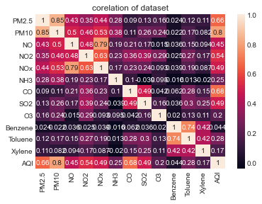

```python
sns.heatmap(corelation, xticklabels=corelation.columns, annot=True)

plt.title("corelation of dataset")
## Reference[5]
```

```python
## Dataframe.corr(): is used to find corelation of various feilds
GG = city_day.corr().AQI.sort_values(ascending = False)
GG
```

```
AQI        1.000000
PM10       0.803313
CO         0.683346
PM2.5      0.659181
NO2        0.537071
SO2        0.490586
NOx        0.486450
NO         0.452191
Toluene    0.279992
NH3        0.252019
O3         0.198991
Xylene     0.165532
Benzene    0.044407
Name: AQI, dtype: float64
```

## Can you generate preliminary visualizations for individual features?

- Yes, some preliminary visualizations have been added in the various features.

## 1. In Which year the percentage of air pollution is high?

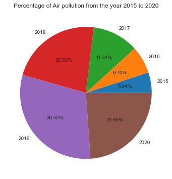

```python
city_day_date.groupby('year').size().plot(kind='pie', figsize=(6, 6), autopct='%1.2f%%')
plt.ylabel("")
plt.title("Percentage of Air pollution from the year 2015 to 2020")
## Reference[3]
```

> In this pie chart, 2019 at peak point in the proportion of air pollution, which was 30.50% and represents by purple colour. The rate of air pollution was quite less in 2015 and 2016,that was 5.04%-6.70%. Ratio of air pollution was mostly equal in the years of 2018 and 2020, it was approximately nearby a quarter whereas in 2017, this percentage was only 11.34%.

## 2. In which season the proportion of air pollution is less?

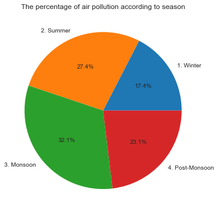

```python
city_day_trans.groupby('Season').size().plot(kind='pie',figsize=(6, 6),autopct='%1.1f%%')
plt.ylabel("")
plt.title("The percentage of air pollution according to season")
## Reference[3]
```

> It is noticed that, in winter, air pollution is very less in comparison to other seasons, that is only 17.4% while the ratio of air pollution in monsoon at highest point, this is about 15% more than winter. Moreover, post-monsoon and summer seasons are both approximately lies in 23.1%-27.4% in the percentage of air pollution.

## 3. Grouping the CO by city and calculating the average CO per city?

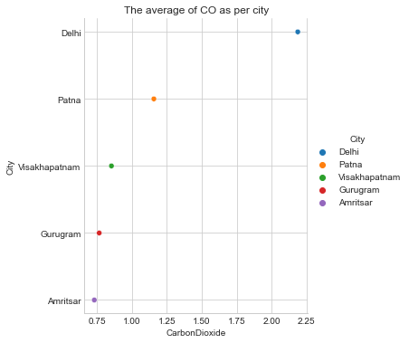

```python
x=pd.DataFrame(AQI_data.groupby(['City'])[['CarbonDioxide']].mean().sort_values(by='CarbonDioxide',ascending=False).head())
x=x.reset_index('City')
plt.figure(figsize=(12,12))
sns.relplot(data=x,x='CarbonDioxide',y='City', hue='City')
plt.title("The average of CO as per city")
## Reference[1]
```

> The graph depicts the average CO per city, with Delhi coming in first with a value of around 2.25 and a dark blue colour. Furthermore, CO levels in Patna are less than 1.25, whereas CO levels in Gurugram and Amritsar are only 0.75, and CO levels in Visakhapatnam are slightly higher than in both cities

## 4. In which city the average of NO gas is higher or lesser?

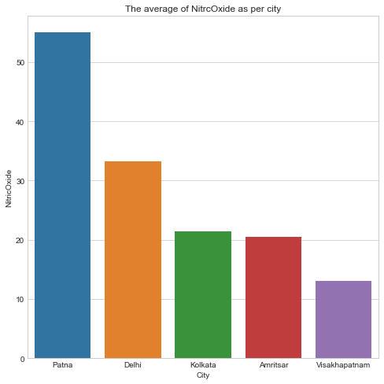

```python
x=pd.DataFrame(AQI_data.groupby(['City'])[['NitricOxide']].mean().sort_values(by='NitricOxide',ascending=False).head())
x=x.reset_index('City')
plt.figure(figsize=(8,8))
sns.barplot(data=x,x='City',y='NitricOxide')
plt.title("The average of NitrcOxide as per city")
## Reference[1]
```

> This graph shows that amount of NO gas in patna city is at the peak which is more than 50 whereas vishakhapatnam is very low which is near about 15. After that the ratio of NO gas in kolkata and amritsar are approximately similar which is about 20. In the case of delhi level of NO gas is 33.

## 5. In which city the average of NO2 gas is higher or lesser?

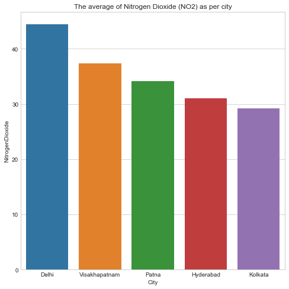

```python
x=pd.DataFrame(AQI_data.groupby(['City'])[['NitrogenDioxide']].mean().sort_values(by='NitrogenDioxide',ascending=False).head())
x=x.reset_index('City')
plt.figure(figsize=(8,8))
sns.barplot(data=x,x='City',y='NitrogenDioxide')
plt.title("The average of Nitrogen Dioxide (NO2) as per city")
## Reference[1]
```

## Fetch the selected values

```python
polluted_city = AQI_data[['City','NitrogenDioxide','NitricOxide','PM2.5','PM10','CarbonDioxide','SulfurDioxide']].groupby(['City']).mean().sort_values(by = 'PM10', ascending = False)
polluted_city
## Reference[2]
```

| City | NitrogenDioxide | NitricOxide | PM2.5 | PM10 | CarbonDioxide | SulfurDioxide |
| --- | --- | --- | --- | --- | --- | --- |
| Delhi | 44.428742 | 33.265458 | 117.134755 | 223.165678 | 2.185964 | 13.948154 |
| Patna | 34.156073 | 55.025393 | 65.831257 | 126.747958 | 1.156911 | 8.596387 |
| Amritsar | 19.048176 | 20.506840 | 56.421509 | 119.936321 | 0.730912 | 9.388129 |
| Gurugram | 17.376891 | 7.842941 | 49.541008 | 113.500672 | 0.766134 | 10.596975 |
| Visakhapatnam | 37.319567 | 13.073855 | 47.372246 | 106.993775 | 0.853510 | 12.819266 |
| Kolkata | 29.197614 | 21.381472 | 47.606294 | 93.489772 | 0.687157 | 8.197487 |
| Hyderabad | 31.059815 | 7.323047 | 46.038925 | 91.945371 | 0.545952 | 9.654258 |
| Chandigarh | 12.031191 | 10.427040 | 39.489783 | 83.123466 | 0.619061 | 10.126173 |
| Amaravati | 23.754613 | 4.576610 | 41.713220 | 81.809876 | 0.611238 | 15.021176 |

## 8. The average of different gases in each city?

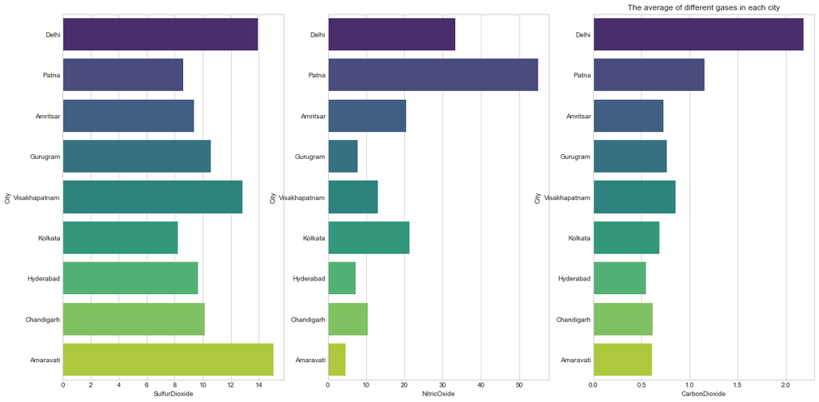

```python
plt.style.use('seaborn-whitegrid')
f, ax_ = plt.subplots(1, 3, figsize = (20,10))

graph1= sns.barplot(x = polluted_city.SulfurDioxide,
                   y = polluted_city.index,
                   palette = 'viridis',
                   ax = ax_[0]);
Graph1 = sns.barplot(x = polluted_city.NitricOxide,
                   y = polluted_city.index,
                   palette = 'viridis',
                   ax = ax_[1]);
Graph1 = sns.barplot(x = polluted_city.CarbonDioxide,
                   y = polluted_city.index,
                   palette = 'viridis',
                   ax = ax_[2]);
plt.title("The average of different gases in each city")
## Reference[2]
```

## 9. Air quality per year

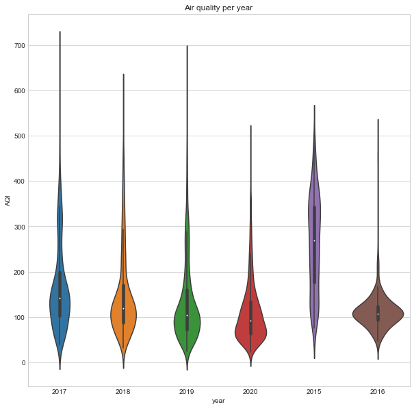

```python
plt.subplots(1, 1, figsize = (10,10))
sns.violinplot(data=c_day, x=city_day_date.year, y='AQI')
plt.title("Air quality per year")
```

> This plot represents the quality of air per year, in 2017 air quality is affected as more than 700, on the other hand the ratio of air quality is very cheap in the year of 2016 and 2020 which was near about 500. Moreover, in 2015 air quality was 580 and there was a difference of 60 can be seen in the year of 2018 and 2019 which was 640 and 700.
- ## References:
1. https://www.kaggle.com/vaishnavipatil4848/indian-air-quality-analysis
2. https://www.kaggle.com/mitramir5/complete-visualization-analysis-and-prediction
3. https://kontext.tech/column/code-snippets/402/pandas-dataframe-plot-pie-chart
4. https://towardsdatascience.com/india-air-pollution-data-analysis-bd7dbfe93841
5. http://seaborn.pydata.org/generated/seaborn.heatmap.html
6. https://www.tutorialspoint.com/write-a-program-in-python-to-split-the-date-column-into-day-month-year-in-multiple-columns-of-a-given-dataframe